# SelectionBias

```r
library(SelectionBias)
```

# Introduction

Selecting a study population from a larger source population, based on the research question, is a common procedure, for example in an observational study with data from a population register. Subjects who fulfill all the selection criteria are included in the study population, and subjects who do not fulfill at least one selection criterion are excluded from the study population. These selections might introduce a systematic error when estimating a causal effect, commonly referred to as selection bias. Selection bias can also arise if the selections are involuntary, for example, if there are dropouts or other missing values for some individuals in the study. In an applied study, it is often of interest to assess the magnitude of potential biases using a sensitivity analysis, such as bounding the bias. Different bounds, the SV (Smith and VanderWeele), AF (assumption-free), GAF (generalized assumption-free), and CAF (counterfactual assumption-free), for the causal estimand under selection bias can be calculated in this R package `SelectionBias`. The content is:

- `zika_learner`: a simulated dataset of zika virus and microcephaly inspired both by data and a previous example (Araújo et al. 2018; Smith and VanderWeele 2019).
- `sensitivityparametersM()`: a function that calculates the sensitivity parameters for the SV and GAF bounds for an assumed model following the M-structure in Figure 1.
- `SVbound()`: a function that calculates the SV bound for the relative risk or risk difference in either the total or subpopulation for sensitivity parameters given by the user, or calculated from `sensitivityparametersM()`.
- `AFbound()`: a function that calculates the AF lower and upper bounds for the relative risk or risk difference in either the total or subpopulation for a dataset or probabilities from the data.
- `GAFbound()`: a function that calculates the GAF lower and upper bounds for the relative risk or risk difference in either the total or subpopulation for a dataset or probabilities from the data and sensitivity parameters either given by the user, or calculated from `sensitivityparametersM()`.
- `CAFbound()`: a function that calculates the CAF lower and upper bounds for the relative risk or risk difference in either the total or subpopulation for a dataset or probabilities from the data and sensitivity parameters.
- `SVboundsharp()`: a function that evaluates if the SV bound for the subpopulation is sharp, inconclusive or not sharp.

For the formulas of the bounds as well as the theory behind them, we refer to the original papers (Smith and VanderWeele 2019; Zetterstrom and Waernbaum 2022, 2023; Zetterstrom 2024).

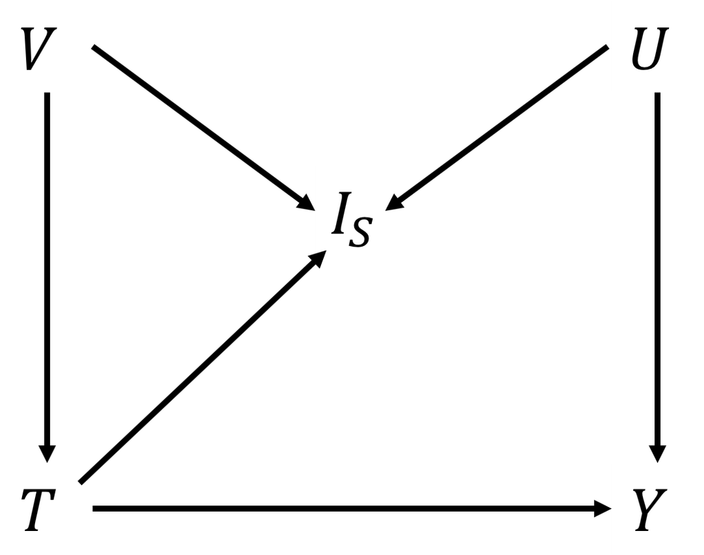

Figure 1. The generalized M-structure.

# R package

## Simulated zika dataset

To illustrate the bounds, a simulated dataset, `zika_learner`, is constructed. It is inspired by a numerical zika example used in Smith and VanderWeele (2019) together with a case-control study that investigates the effect of zika virus on microcephaly (Araújo et al. 2018). The variables included are:

- *Living area* $(V)$
- *Socioeconomic status, SES* $(U)$
- *Zika* $(T)$
- *Microcephaly* $(Y)$
- *Birth* $(S_1)$
- *Public hospital* $(S_2)$

The relationships between the variables are illustrated in Figure 2 and Table 1. The prevalences of the variables, and strengths of dependencies between them, are chosen to mimic real data and the assumed values for the sensitivity parameters in Smith and VanderWeele (2019). The simulated data mimics a cohort with 5000 observations, even though the original study is a case-control study. For more details of the variables and the models, see Zetterstrom and Waernbaum (2023).

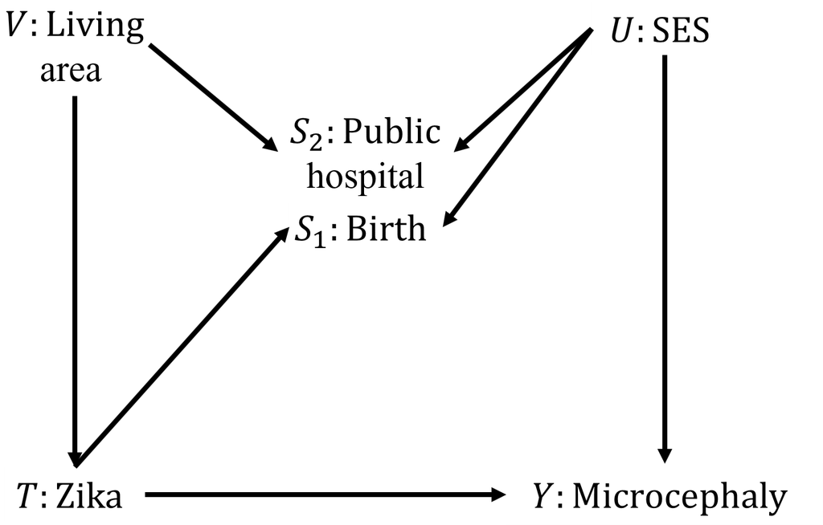

Figure 2. Causal model for the `zika_learner` dataset.

Table 1. Data generating process for the dataset `zika_learner`. Models generating causal dependencies are logistic, $g(X'\theta)$, for predictor variable $X$ and model parameter $\theta$.

| Model | Coefficients ($\theta$)/Proportions | Function argument |
| --- | --- | --- |
| $P(V=1)$ | $0.85$ | `Vval` |
| $P(U=1)$ | $0.50$ | `Uval` |
| $P(T=1\|V)=g(V'\theta_T)$ | $(-6.20,1.75)$ | `Tcoef` |
| $P(Y=1\|T,U)=g[(T,U)'\theta_{Y}]$ | $(-5.20,5.00,-1.00)$ | `Ycoef` |
| $P(S_1=1\|T,U)=g[(V,U,T)'\theta_{S1}]$ | $(1.20,0.00,2.00,-4.00)$ | `Scoef` |
| $P(S_2=1\|T,U)=g[(V,U,T)'\theta_{S1}]$ | $(2.20,0.50,-2.75,0.00)$ | `Scoef` |

The data was generated in `R`, version 4.2.0, using the package `arm`, version 1.13-1, with the following code:

```r
# Seed.
set.seed(158118)

# Number of observations.
nObs = 5000

# The unmeasured variable, living area (V).
urban = rbinom(nObs, 1, 0.85)

# The treatment variable, zika.
zika_prob = arm::invlogit(-6.2 + 1.75 * urban)
zika = rbinom(nObs, 1, zika_prob)

# The unmeasured variable, SES (U).
SES = rbinom(nObs, 1, 0.5)

# The outcome variable, microcephaly.
mic_ceph_prob = arm::invlogit(-5.2 + 5 * zika - 1 * SES)
mic_ceph = rbinom(nObs, 1, mic_ceph_prob)

# The first selection variable, birth.
birth_prob = arm::invlogit(1.2 - 4 * zika + 2 * SES)
birth = rbinom(nObs, 1, birth_prob)

# The second selection variable, hospital.
hospital_prob = arm::invlogit(2.2 + 0.5 * urban - 2.75 * SES)
hospital = rbinom(nObs, 1, hospital_prob)

# The selection indicator.
sel_ind = birth * hospital
```

The resulting proportions of the `zika_learner` data, for the total dataset, the subset with $S_1=1$ and the subset with $S_1=S_2=1$ are seen in Tables 2-4.

Table 2. Proportions for the simulated dataset, by treatment status and overall.

|  | Not zika infected (N=4939) | Zika infected (N=61) | Overall (N=5000) |
| --- | --- | --- | --- |
| Microcephaly |  |  |  |
| Mean | 0.003 | 0.361 | 0.008 |
| Living area |  |  |  |
| Mean | 0.849 | 0.951 | 0.850 |
| SES |  |  |  |
| Mean | 0.499 | 0.426 | 0.498 |

Table 3. Proportions for the simulated dataset, by treatment status and overall, after the first selection.

|  | Not zika infected (N=4268) | Zika infected (N=11) | Overall (N=4279) |
| --- | --- | --- | --- |
| Microcephaly |  |  |  |
| Mean | 0.003 | 0.273 | 0.004 |
| Living area |  |  |  |
| Mean | 0.845 | 1.000 | 0.846 |
| SES |  |  |  |
| Mean | 0.556 | 0.818 | 0.557 |

Table 4. Proportions for the simulated dataset, by treatment status and overall, after both selections.

|  | Not zika infected (N=2869) | Zika infected (N=7) | Overall (N=2876) |
| --- | --- | --- | --- |
| Microcephaly |  |  |  |
| Mean | 0.004 | 0.286 | 0.005 |
| Living area |  |  |  |
| Mean | 0.858 | 1.000 | 0.858 |
| SES |  |  |  |
| Mean | 0.382 | 0.714 | 0.382 |

The dataset and data generating process (DGP) can be used to test the functions in `SelectionBias`.

## `sensitivityparametersM()`

The sensitivity parameters for the SV and GAF bounds are calculated for the generalized M-structure, illustrated in Figure 1. The sensitivity parameters are only calculated for an assumed model structure, since they depend on the unobserved variable, *U*. However, the observed probabilities of the outcome, $P(Y=1|T=t,I_S=1)$, $t=0,1$, are inputs as they are used to check if the causal estimand for the assumed DGP is greater or smaller than the observational estimand since the SV bound only is defined when the causal estimand is smaller than the observational estimand. If not, the treatment variable must be recoded. This is not an issue for the GAF bound since both a lower and upper bound is available. The code and the output are:

```r
# SV bound
sensitivityparametersM(whichEst = "RR_tot",
                   whichBound = "SV",
                   Vval = matrix(c(1, 0, 0.85, 0.15), ncol = 2),
                   Uval = matrix(c(1, 0, 0.5, 0.5), ncol = 2),
                   Tcoef = c(-6.2, 1.75),
                   Ycoef = c(-5.2, 5.0, -1.0),
                   Scoef = matrix(c(1.2, 2.2, 0.0, 0.5,
                                    2.0, -2.75, -4.0, 0.0),
                                  ncol = 4),
                   Mmodel = "L",
                   pY1_T1_S1 = 0.286,
                   pY1_T0_S1 = 0.004)
```

```
#>      [,1]                [,2]
#> [1,] "BF_1"              1.3895
#> [2,] "BF_0"              1.3208
#> [3,] "RR_UY|T=1"         2.7089
#> [4,] "RR_UY|T=0"         1.9448
#> [5,] "RR_SU|T=1"         1.7998
#> [6,] "RR_SU|T=0"         1.9998
#> [7,] "Reverse treatment" TRUE
```

```r
# GAF bound
sensitivityparametersM(whichEst = "RR_tot",
                   whichBound = "GAF",
                   Vval = matrix(c(1, 0, 0.85, 0.15), ncol = 2),
                   Uval = matrix(c(1, 0, 0.5, 0.5), ncol = 2),
                   Tcoef = c(-6.2, 1.75),
                   Ycoef = c(-5.2, 5.0, -1.0),
                   Scoef = matrix(c(1.2, 2.2, 0.0, 0.5,
                                    2.0, -2.75, -4.0, 0.0),
                                  ncol = 4),
                   Mmodel = "L",
                   pY1_T1_S1 = 0.286,
                   pY1_T0_S1 = 0.004)
```

```
#>      [,1]  [,2]
#> [1,] "m_T" 0.002
#> [2,] "M_T" 0.4502
```

In the zika example, the estimand of interest is the relative risk in the total population, `whichEst = "RR_tot"`, the DGP is found in Table 1, logistic models are used in the DGP and the probabilities are found in Table 4. For the SV bound, the output is $RR_{UY|T=1}=2.71$, $RR_{UY|T=0}=1.94$, $RR_{SU|T=1}=1.80$, and $RR_{SU|T=0}=2.00$, which gives $BF_1=1.39$ and $BF_0=1.32$, and the treatment coding is reversed. For the GAF bound, the output is $M_T=0.4502$ and $m_T=0.002$.

## `SVbound()`

The SV bound can be calculated using the function `SVbound()`. The first argument is `whichEst`, indicating the causal estimand of interest (`"RR_tot"`, `"RD_tot"`, `"RR_sub"` or `"RD_sub"`). The second and third arguments are the observed conditional probabilities $P(Y=1|T=1,I_S=1)$ and $P(Y=1|T=0,I_S=1)$, which are needed to calculate bounds for the causal estimands and not the selection bias itself. The subsequent arguments are the sensitivity parameters provided by the user. The default value for all sensitivity parameters are `NULL`, and the user must then specify numeric values on the sensitivity parameters that are necessary for the bound for the chosen estimand. The sensitivity parameters can either be calculated using the function `sensitivityparametersM()`, or found elsewhere. For sensitivity parameters found elsewhere, `SVbound()` is not restricted to the generalized M-structure. However, the necessary assumptions for the SV bound must still be fulfilled (Smith and VanderWeele 2019). The output is the SV bound. The code and output are:

```r
SVbound(whichEst = "RR_tot",
        pY1_T1_S1 = 0.004,
        pY1_T0_S1 = 0.286,
        RR_UY_T1 = 2.71,
        RR_UY_T0 = 1.94,
        RR_SU_T1 = 1.80,
        RR_SU_T0 = 2.00)
```

```
#>      [,1]       [,2]
#> [1,] "SV bound" 0.01
```

As before in the zika example, the causal estimand is the relative risk in the total population, `whichEst = "RR_tot"`. The sensitivity parameters are $RR_{UY|T=1}=2.71$, $RR_{UY|T=0}=1.94$, $RR_{SU|T=1}=1.80$, and $RR_{SU|T=0}=2.00$, calculated above in `sensitivityparametersM()`, which gives an SV bound equal to 0.01. If the causal estimand is underestimated, the recoding of the treatment must be done manually.

## `SVboundsharp()`

The sharpness of an SV bound can be evaluated using `SVboundsharp()` (Zetterstrom and Waernbaum 2023). However, it is only bounds for the relative risk in the subpopulation that can be sharp. The first argument, `BF_U`, is the value of $BF_U$ which can be calculated using `sensitivityparametersM`. The second argument, `pY1_T0_S1`, is the probability $P(Y=1|T=0,I_S=1)$. The output is a string stating whether the SV bound is sharp or inconclusive. The code and output are:

```r
SVboundsharp(BF_U = 1.56,
             pY1_T0_S1 = 0.27)
```

```
#> [1] "SV bound is sharp."
```

We are actually interested in bounds for the relative risk in the total population in the zika example but to demonstrate the function we check if the bound for the relative risk in the subpopulation is sharp. Thus, $BF_U=1.56$ and $P(Y=1|T=0,I_S=1)=0.27$ (calculated from `sensitivityparametersM()` and the `zika_learner`). Note that if the causal estimand is underestimated, the recoding of the treatment has to be done manually. In this setting, the SV bound is sharp. As before, the bias is negative, and we have reversed the coding of the treatment.

## `AFbound()`

The AF bound is calculated using the function `AFbound()`. The first argument is the causal estimand of interest (`"RR_tot"`, `"RD_tot"`, `"RR_sub"` or `"RD_sub"`). The second argument is `outcome`, where the user inputs either the observed numeric vector with the outcome variable or a vector with the conditional outcome probabilities, $P(Y=1|T=1,I_S=1)$ and $P(Y=1|T=0,I_S=1)$. The third argument is `treatment`, where the user inputs either the observed numeric vector with the treatment variable or a vector with the conditional treatment probabilities, $P(T=1|I_S=1)$ and $P(T=0|I_S=1)$. The fourth argument is `selection` where the user can either input the observed selection vector or the selection probability. Its default value is `NULL` since it is only required when the causal estimands in the total population are of interest. If the subpopulation is of interest and `selection = NULL`, the outcome and treatment vectors must only include the selected subjects. The output is the lower and upper AF bounds. The code and output are:

```r
attach(zika_learner)

AFbound(whichEst = "RR_tot",
        outcome = mic_ceph[sel_ind == 1],
        treatment = zika[sel_ind == 1],
        selection = mean(sel_ind))
```

```
#>      [,1]             [,2]
#> [1,] "AF lower bound" 0
#> [2,] "AF upper bound" 454.09
```

Similar to before, `whichEst = "RR_tot"`. Furthermore, the outcome and treatment variables are microcephaly and zika. The selection probability is specified since the other variables are restricted to those subjects with $I_S=1$. The output is the lower and upper AF bounds, which are 0 and 454.09 in the zika example.

If the raw data is not available, one can input the conditional probabilities instead. In this example, these probabilities are:

```r
AFbound(whichEst = "RR_tot",
        outcome = c(0.286, 0.004),
        treatment = c(0.002, 0.998),
        selection = mean(sel_ind))
```

```
#>      [,1]             [,2]
#> [1,] "AF lower bound" 0
#> [2,] "AF upper bound" 435.14
```

The difference in these two examples comes from rounding errors. Note that the treatment does not need to be recoded since there is both a lower and upper bound. Please have this in mind when comparing the bounds to the SV bound.

## `GAFbound()`

The GAF bound is calculated using the function `GAFbound()`. The first argument is the causal estimand of interest (`"RR_tot"`, `"RD_tot"`, `"RR_sub"` or `"RD_sub"`). The second and third arguments are `M` and `m` which are the two sensitivity parameters for the GAF bound. The sensitivity parameters can either be calculated using `sensitivityparametersM()`, or found elsewhere. For sensitivity parameters found elsewhere, `GAFbound()` is not restricted to the generalized M-structure. However, the necessary assumptions for the GAF bound must still be fulfilled (Zetterstrom 2024). The fourth argument is `outcome`, where the user inputs either the observed numeric vector with the outcome variable or a vector with the conditional outcome probabilities, $P(Y=1|T=1,I_S=1)$ and $P(Y=1|T=0,I_S=1)$. The fifth argument is `treatment`, where the user inputs either the observed numeric vector with the treatment variable or a vector with the conditional treatment probabilities, $P(T=1|I_S=1)$ and $P(T=0|I_S=1)$. The sixth argument is `selection` where the user can either input the observed selection vector or selection probability. Its default value is `NULL` since it is only required when the causal estimands in the total population are of interest. If the subpopulation is of interest and `selection = NULL`, the outcome and treatment vectors must only include the selected subjects. The output is the lower and upper GAF bounds. The code and output are:

```r
GAFbound(whichEst = "RR_tot",
         M = 0.4502,
         m = 0.002,
         outcome = mic_ceph[sel_ind == 1],
         treatment = zika[sel_ind == 1],
         selection = mean(sel_ind))
```

```
#>      [,1]              [,2]
#> [1,] "GAF lower bound" 0.01
#> [2,] "GAF upper bound" 147.42
```

Similar to before, `whichEst = "RR_tot"`. The sensitivity parameters are the output from `sensitivityparametersM()`. Furthermore, the outcome and treatment variables are microcephaly and zika. The selection probability is specified since the other variables are restricted to those subjects with $I_S=1$. The output is the lower and upper GAF bounds, which are 0.01 and 147.42 in the zika example.

If the raw data is not available, one can input the conditional probabilities instead, similar to the AF bound. Note that the treatment does not need to be recoded since there is both a lower and upper bound. Please have this in mind when comparing the bounds to the SV bound.

## `CAFbound()`

The CAF bound is calculated using the function `CAFbound()`. The first argument is the causal estimand of interest (`"RR_tot"`, `"RD_tot"`, `"RR_sub"` or `"RD_sub"`). The second and third arguments are `M` and `m` which are the two sensitivity parameters for the CAF bound. The fourth argument is `outcome`, where the user inputs either the observed numeric vector with the outcome variable or a vector with the conditional outcome probabilities, $P(Y=1|T=1,I_S=1)$ and $P(Y=1|T=0,I_S=1)$. The fifth argument is `treatment`, where the user inputs either the observed numeric vector with the treatment variable or a vector with the conditional treatment probabilities, $P(T=1|I_S=1)$ and $P(T=0|I_S=1)$. The sixth argument is `selection` where the user can either input the observed selection vector or selection probability. Its default value is `NULL` since it is only required when the causal estimands in the total population are of interest. If the subpopulation is of interest and `selection = NULL`, the outcome and treatment vectors must only include the selected subjects. The output is the lower and upper CAF bounds. The code and output are:

```r
CAFbound(whichEst = "RR_tot",
         M = 0.3,
         m = 0.005,
         outcome = c(0.286, 0.004),
         treatment = c(0.002, 0.998),
         selection = mean(sel_ind))
```

```
#>      [,1]              [,2]
#> [1,] "CAF lower bound" 0.04
#> [2,] "CAF upper bound" 67.78
```

Similar to before, `whichEst = "RR_tot"`. The sensitivity parameters are chosen by the user. Furthermore, the outcome and treatment variables are microcephaly and zika. The selection probability is specified since other variables are restricted to those subjects with $I_S=1$. The output is the lower and upper CAF bounds, which are 0.04 and 67.78 in the zika example.

If the raw data is not available, one can input the conditional probabilities instead, similar to the AF and GAF bounds. Note that the treatment does not need to be recoded since there is both a lower and upper bound. Please have this in mind when comparing the bounds to the SV bound.

# References

Araújo, Thalia Velho Barreto de, Ricardo Arraes de Alencar Ximenes, Demócrito de Barros Miranda-Filho, Wayner Vieira Souza, Ulisses Ramos Montarroyos, Ana Paula Lopes de Melo, Sandra Valongueiro, et al. 2018. “Association Between Microcephaly, Zika Virus Infection, and Other Risk Factors in Brazil: Final Report of a Case-Control Study.” *The Lancet Infectious Diseases* 18 (3): 328–36.

Smith, Louisa H, and Tyler J VanderWeele. 2019. “Bounding Bias Due to Selection.” *Epidemiology* 30 (4): 509–16.

Zetterstrom, Stina. 2024. “Bounds for Selection Bias Using Outcome Probabilities.” *Epidemiologic Methods* 13 (1): 20230033.

Zetterstrom, Stina, and Ingeborg Waernbaum. 2022. “Selection Bias and Multiple Inclusion Criteria in Observational Studies.” *Epidemiologic Methods* 11 (1): 1–21.

———. 2023. “SelectionBias: An R Package for Bounding Selection Bias.” arXiv. https://doi.org/10.48550/ARXIV.2302.06518.